# Homework 09

Joe Dickerson

2025-04-04

```r
library(faraway)
library(tidyverse)
library(lme4)
library(lattice)
## library(nlme)

data(coagulation)
```

2. The coagulation dataset comes from a study of blood coagulation times. Twenty-four animals were randomly assigned to four different diets and the samples were taken in a random order.
1. Plot the data and comment.

We see generally higher blood coagulation times with diets B and C, and lower with diets A and D. The lowest (quickest) times for diet B overlap with the highest (slowest) times for diets A and D.

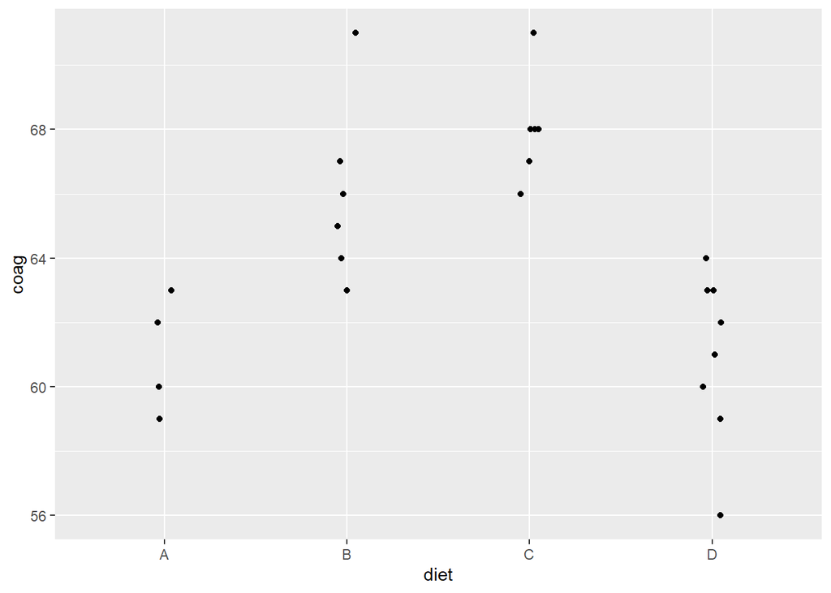

```r
coagulation %>% ggplot(aes(x = diet, y = coag)) +
  geom_point(position = position_jitter(width = 0.05, height = 0))
```

2. Fit a fixed effects model and construct a prediction together with a 95% prediction interval for the response of a new animal assigned to diet D.

```r
lmod <- aov(coag ~ diet, coagulation)
summary(lmod)
```

```
##             Df Sum Sq Mean Sq F value   Pr(>F)
## diet         3    228    76.0   13.57 4.66e-05 ***
## Residuals   20    112     5.6
## ---
## Signif. codes:  0 '***' 0.001 '**' 0.01 '*' 0.05 '.' 0.1 ' ' 1
```

```r
df_new <- data.frame(diet = "D")

predict(lmod, newdata = df_new, interval = "prediction", level = 0.95)
```

```
##   fit      lwr      upr
## 1  61 55.76427 66.23573
```

3. Now fit a random effects model using REML. A new animal is assigned to diet D. Predict the blood coagulation time for this animal along with a 95% prediction interval.

We have a best linear unbiased predictor for blood coagulation time as 61.17 for a new animal on diet D. We see this both with the predict() function and by checking the random effect of diet D with ranef(), subtracting 2.842495 from our intercept of 64.01. We get a prediction interval using the bootstrap method.

```r
mmod <- lmer(coag ~ 1 + (1|diet), coagulation)

summary(mmod)
```

```
## Linear mixed model fit by REML ['lmerMod']
## Formula: coag ~ 1 + (1 | diet)
##    Data: coagulation
##
## REML criterion at convergence: 115.8
##
## Scaled residuals:
##      Min       1Q   Median       3Q      Max
## -2.18491 -0.59921  0.09332  0.54078  2.17508
##
## Random effects:
##  Groups   Name        Variance Std.Dev.
##  diet     (Intercept) 11.692   3.419
##  Residual              5.599   2.366
## Number of obs: 24, groups:  diet, 4
##
## Fixed effects:
##             Estimate Std. Error t value
## (Intercept)    64.01       1.78   35.96
```

```r
## The fixed model intercept combined with random effect mode of diet D is equal to our prediction

fixef(mmod)+ranef(mmod)$diet
```

```
##   (Intercept)
## A    61.32214
## B    65.85309
## C    67.70525
## D    61.17017
```

```r
predict(mmod, newdata = data.frame(diet="D"), interval = "prediction", level = 0.95)
```

```
##        1
## 61.17017
```

```r
set.seed(123)

group.sd <- as.data.frame(VarCorr(mmod))$sdcor[1]
resid.sd <- as.data.frame(VarCorr(mmod))$sdcor[2]

pv <- numeric(1000)

for(i in 1:1000){
  y <- unlist(simulate(mmod, use.u=TRUE))
  bmod <- refit(mmod, y)
  pv[i] <- predict(bmod, newdata=data.frame(diet="D"))  + rnorm(n=1,sd=resid.sd)
}

pred_interval <- quantile(pv, c(0.025, 0.975))

pred_interval
```

```
##     2.5%    97.5%
## 56.69907 66.22767
```

4. A new diet is given to a new animal. Predict the blood coagulation time for this animal along with a 95% prediction interval.

The prediction interval is found with the bootstrap method. We expect the blood coagulation time to be 64.

```r
# confint(mmod, method = "boot")

set.seed(123)

group.sd <- as.data.frame(VarCorr(mmod))$sdcor[1]
resid.sd <- as.data.frame(VarCorr(mmod))$sdcor[2]

pv <- numeric(1000)

for(i in 1:1000){
  y <- unlist(simulate(mmod))
  bmod <- refit(mmod, y)
  pv[i] <- predict(bmod, re.form=~0)[1] + rnorm(n=1,sd=group.sd) +
  rnorm(n=1,sd=resid.sd)
}

pred_interval_2 <- quantile(pv, c(0.025, 0.975))

pred_interval_2
```

```
##     2.5%    97.5%
## 54.78558 72.62177
```

```r
mean(predict(mmod, method = "boot"))
```

```
## [1] 64
```

5. A new diet is given to the first animal in the dataset. Predict the blood coagulation time for this animal with a prediction interval. You may assume that the effects of the initial diet for this animal have washed out.

Because the animals are independent from each other, we would expect the same interval for the first animal as one that is introduced after the study, so the prediction interval is the same as part D. We specify the first animal in the dataset when we predict and have a prediction of 61.32214.

```r
pred_interval_2
```

```
##     2.5%    97.5%
## 54.78558 72.62177
```

```r
predict(mmod, reform = ~0)[1]
```

```
##        1
## 61.32214
```